# aas

Rayssa

5 de junho de 2017

```r
dados <- read_csv("../dados/series_from_imdb.csv")
subconjunto <- dados %>% filter(series_name %in% c("13 Reasons Why", "Dexter", "Prison Break"))
```

# Perguntas

**a. Qual das séries que você escolheu é mais bem avaliada no IMDB? A diferença é grande? Pequena?**

Para verificar qual dentre as séries (13 Reasons Why, Dexter e Prison Break) é a mais bem avaliada, precisamos da média da avaliação dos usuários para cada série, desta forma a série que possuir a maior média será a mais bem avaliada. Portanto, será mostrado detalhadamente logo abaixo através de histogramas, boxplot e sumário o referente a cada série.

## 13 Reasons Why

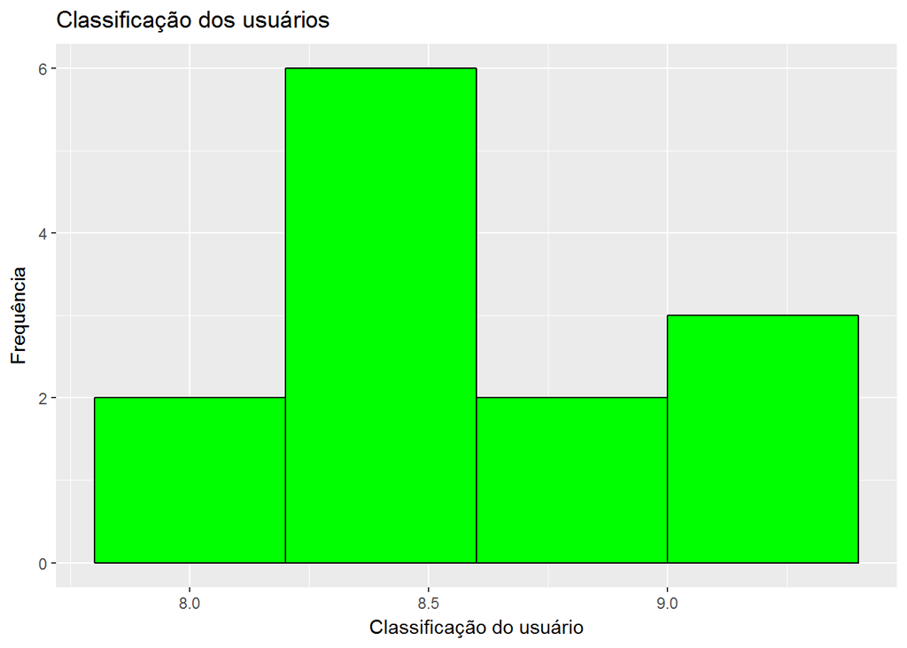

```r
dados %>%
  filter(series_name == "13 Reasons Why") %>%
    ggplot(aes(x = UserRating)) +
    geom_histogram(binwidth = .4, fill = "green", color = "black") +
    labs(title = "Classificação dos usuários", x="Classificação do usuário", y = "Frequência")
```

Com as informações mostradas no histograma acima, podemos perceber visualmente que a maior frequência está na classificação 8.5. Para confirmarmos esta afirmação verificamos a mediana da série ‘13 Reason Why’ através do boxplot…

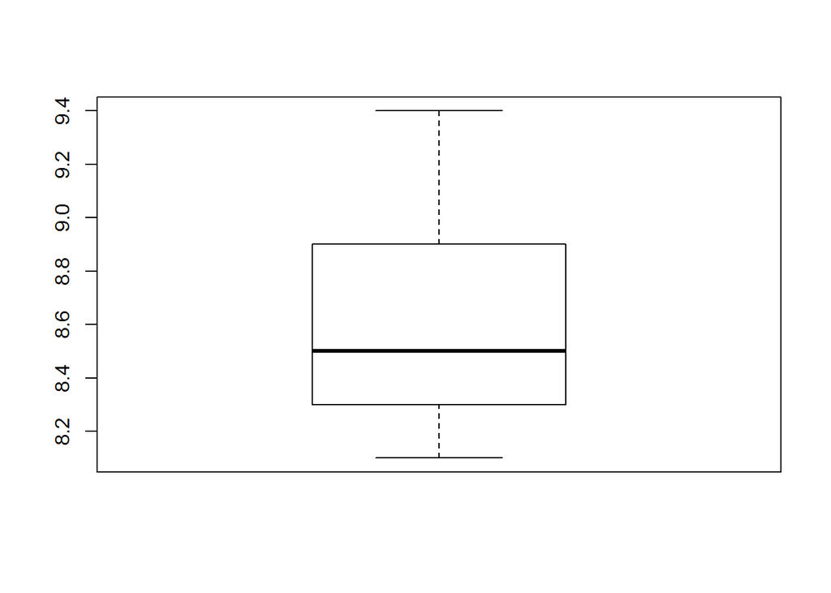

```r
boxplot((dados %>%  filter(series_name == "13 Reasons Why"))$UserRating)
```

```r
summary((dados %>%  filter(series_name == "13 Reasons Why"))$UserRating)
```

```
##    Min. 1st Qu.  Median    Mean 3rd Qu.    Max.
##   8.100   8.300   8.500   8.654   8.900   9.400
```

## Dexter

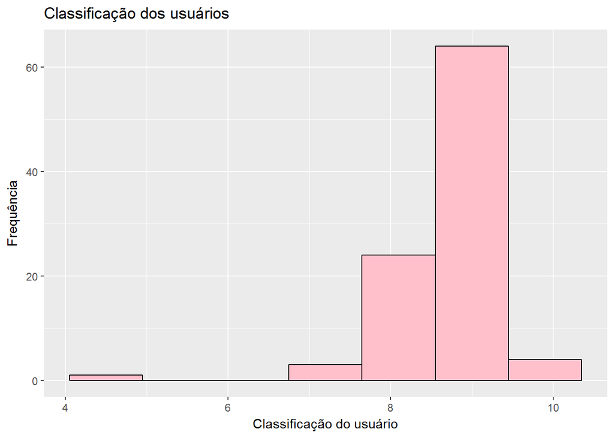

```r
dados %>%
  filter(series_name == "Dexter") %>%
    ggplot(aes(x = UserRating)) +
    geom_histogram(binwidth = .9, fill = "pink", color = "black") +
    labs(title = "Classificação dos usuários", x="Classificação do usuário", y = "Frequência")
```

Como podemos perceber no boxplot, há existência de outliers (‘ponto fora da curva’) que corresponde a um ponto que está muito distante das demais observações. Ele pode indicar que há muita variação dos dados ou algum erro de mensuração. Para tratar esses outliers é preciso utilizar uma estatística mais robusta: a mediana.

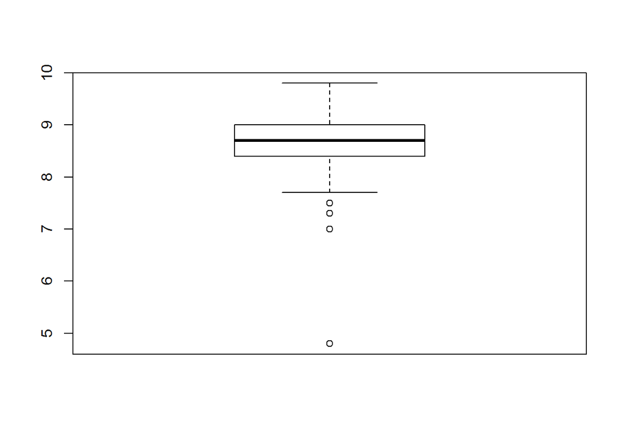

```r
boxplot((dados %>%  filter(series_name == "Dexter"))$UserRating)
```

Como a mediana consegue desconsiderar os pontos fora da curva, podemos observar com a maior exatidão os dados, no caso dessa série tem-se como mediana igual a 8.700.

```r
summary((dados %>%  filter(series_name == "Dexter"))$UserRating)
```

```
##    Min. 1st Qu.  Median    Mean 3rd Qu.    Max.
##   4.800   8.400   8.700   8.649   9.000   9.800
```

## Prison Break

Da mesma forma que foi realizado com as demais séries, é preciso analisar as informações da série Prison Break.

O histograma mostra que a média da nota dos usuários foi aproximadamente 8.5.

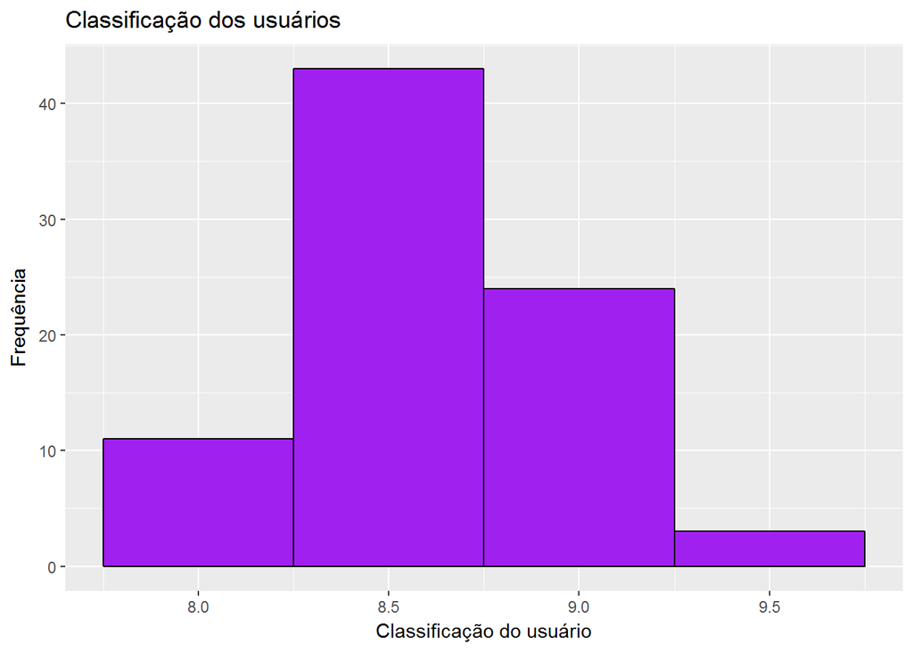

```r
dados %>%
  filter(series_name == "Prison Break") %>%
    ggplot(aes(x = UserRating)) +
    geom_histogram(binwidth = .5, fill = "purple", color = "black") +
    labs(title = "Classificação dos usuários", x="Classificação do usuário", y = "Frequência")
```

Como podemos perceber no boxplot, a mediana mostra um valor um pouco acima de 8.5.

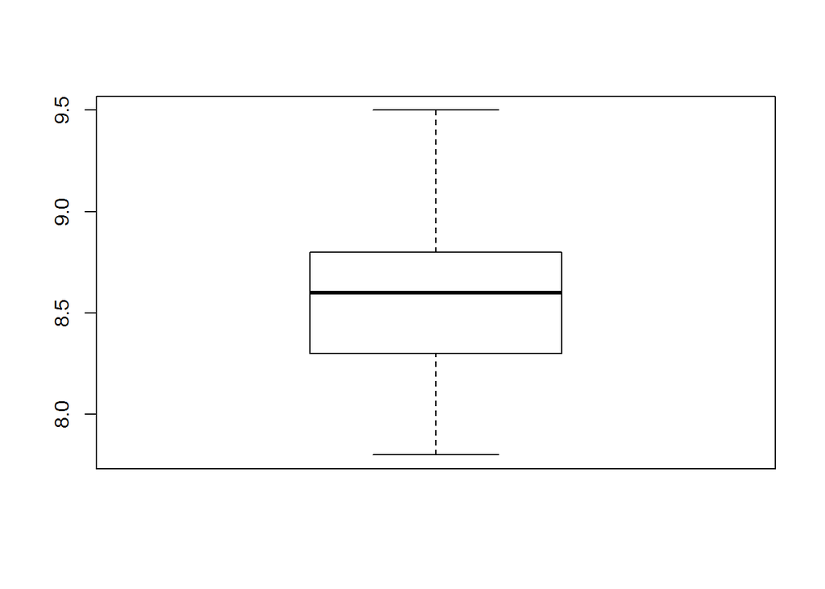

```r
boxplot((dados %>%  filter(series_name == "Prison Break"))$UserRating)
```

Para saber com exatidão o valor da mediana utilizamos os valores fornecidos pelo sumário, neste caso essa série possui mediana 8.600.

```r
summary((dados %>%  filter(series_name == "Prison Break"))$UserRating)
```

```
##    Min. 1st Qu.  Median    Mean 3rd Qu.    Max.
##   7.800   8.300   8.600   8.621   8.800   9.500
```

**b. Qual das séries que você escolheu tem episódios de qualidade mais irregular segundo o IMDB? A diferença é grande? Pequena?**

Levando em consideração que a irregularidade na qualidade dos episódios corresponde a falta de disposição de aumento ou diminuição na avaliação dos usuários durante os episódios, iremos analisar essas informações pelo gráfico de linha objetivando uma melhor visualização dos dados.

## 13 Reasons Why

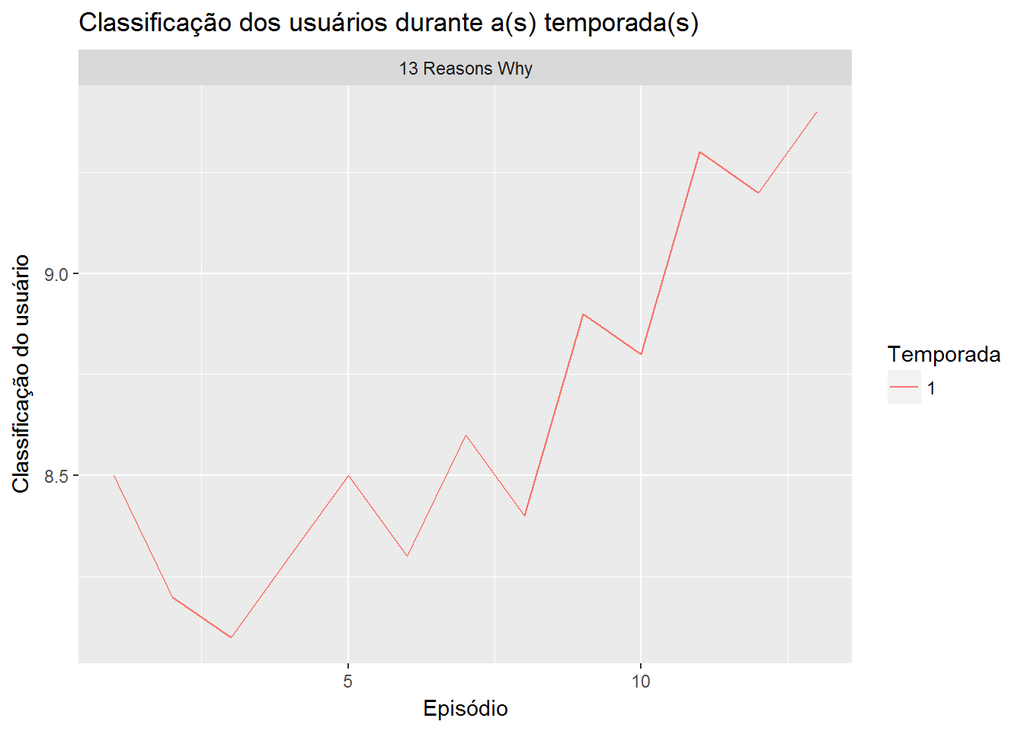

```r
dados %>% filter(series_name == "13 Reasons Why")  %>%
  ggplot(aes(series_ep, UserRating, color = as.factor(season))) +
  geom_line() +
  facet_wrap(~ series_name) +
  labs(x = "Episódio", y = "Classificação do usuário", color = "Temporada", title = "Classificação dos usuários durante a(s) temporada(s)")
```

## Dexter

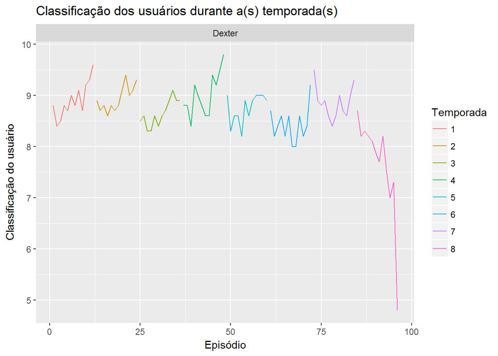

```r
dados %>% filter(series_name == "Dexter")  %>%
  ggplot(aes(series_ep, UserRating, color = as.factor(season))) +
  geom_line() +
  facet_wrap(~ series_name) +
  labs(x = "Episódio", y = "Classificação do usuário", color = "Temporada", title = "Classificação dos usuários durante a(s) temporada(s)")
```

## Prison Break

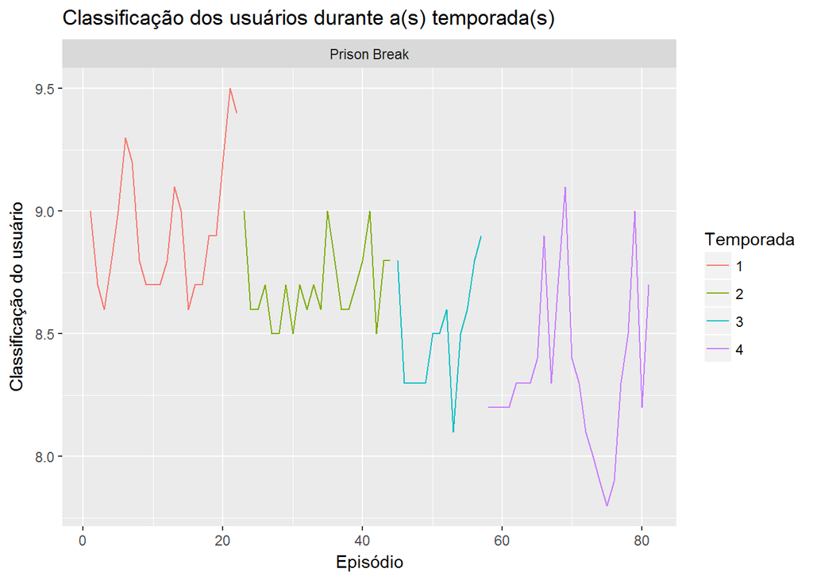

```r
dados %>% filter(series_name == "Prison Break")  %>%
  ggplot(aes(series_ep, UserRating, color = as.factor(season))) +
  geom_line() +
  facet_wrap(~ series_name) +
  labs(x = "Episódio", y = "Classificação do usuário", color = "Temporada", title = "Classificação dos usuários durante a(s) temporada(s)")
```

Podemos observar que a série ‘13 Reasons Why’ apresenta uma tendência de aumento nas avaliações a medida que os episódios irão sendo reproduzidos, durante a maior parte da temporada. Dentre as outras duas séries a que mais apresenta irregularidade na qualidade dos episódios é a ‘Dexter’ pois há uma maior variação nos valores das notas dadas pelos usuários.